# Funnel analysis & A/B testing

Goal: To find a way to raise the share of completed purchases by studying the sales funnel; to find out how the conducted A/A/B test has affected the user behavior.

Step 1. General Information and preprocessing  
Step 2. General data analysis  
Step 3. Funnlel analysis

- Funnel graph
- Funnel analysis conclusion

Step 4. The test results

- A/A test results
- Groups funnel graph
- A/A/B test total conclusions

Step 5. Overall conclusion

### Step 1. General information and preprocessing

```python
import plotly.express as px
from plotly import graph_objects as go
import pandas as pd
import numpy as np
import math as mth
import matplotlib.pyplot as plt
from matplotlib.pyplot import figure
from scipy import stats as st
import seaborn as sns
import re

logs_df = pd.read_csv(r'C:\Users\RoG\Desktop\Yandex_Course\logs_exp_us.csv', sep='\t')
logs_df.sample()
```

|  | EventName | DeviceIDHash | EventTimestamp | ExpId |
| --- | --- | --- | --- | --- |
| 27041 | PaymentScreenSuccessful | 6985989271562289673 | 1564674208 | 246 |

```python
logs_df.info(memory_usage='deep')
```

```
<class 'pandas.core.frame.DataFrame'>
RangeIndex: 244126 entries, 0 to 244125
Data columns (total 4 columns):
 #   Column          Non-Null Count   Dtype
---  ------          --------------   -----
 0   EventName       244126 non-null  object
 1   DeviceIDHash    244126 non-null  int64
 2   EventTimestamp  244126 non-null  int64
 3   ExpId           244126 non-null  int64
dtypes: int64(3), object(1)
memory usage: 22.9 MB
```

`The data is heavy, it'd be better to lower the memory usage.`

```python
logs_df.columns = ['event', 'uid', 'ts', 'group']
```

```python
logs_df.event.value_counts()
```

```
MainScreenAppear           119205
OffersScreenAppear          46825
CartScreenAppear            42731
PaymentScreenSuccessful     34313
Tutorial                     1052
Name: event, dtype: int64
```

`Event names may be convertted to category type.`

```python
logs_df['event'] = logs_df['event'].astype('category')
```

```python
logs_df.info(memory_usage='deep')
```

```
<class 'pandas.core.frame.DataFrame'>
RangeIndex: 244126 entries, 0 to 244125
Data columns (total 4 columns):
 #   Column  Non-Null Count   Dtype
---  ------  --------------   -----
 0   event   244126 non-null  category
 1   uid     244126 non-null  int64
 2   ts      244126 non-null  int64
 3   group   244126 non-null  int64
dtypes: category(1), int64(3)
memory usage: 5.8 MB
```

`It resulted in a significant reduction in memory usage.`

```python
logs_df.duplicated().value_counts()
```

```
False    243713
True        413
dtype: int64
```

`There are 413 duplicated rows. Let's delete them.`

```python
idx_true = logs_df.duplicated()[logs_df.duplicated() == True].index
logs_df = logs_df.drop(index=idx_true)
```

```python
logs_df.min()
```

```
event    CartScreenAppear
uid      6888746892508752
ts             1564029816
group                 246
dtype: object
```

`There are no zero values in columns.`

```python
logs_df['dt'] = pd.to_datetime(logs_df['ts'], unit='s')
logs_df['date'] = logs_df['dt'].dt.date
```

```python
logs_df.head()
```

|  | event | uid | ts | group | dt | date |
| --- | --- | --- | --- | --- | --- | --- |
| 0 | MainScreenAppear | 4575588528974610257 | 1564029816 | 246 | 2019-07-25 04:43:36 | 2019-07-25 |
| 1 | MainScreenAppear | 7416695313311560658 | 1564053102 | 246 | 2019-07-25 11:11:42 | 2019-07-25 |
| 2 | PaymentScreenSuccessful | 3518123091307005509 | 1564054127 | 248 | 2019-07-25 11:28:47 | 2019-07-25 |
| 3 | CartScreenAppear | 3518123091307005509 | 1564054127 | 248 | 2019-07-25 11:28:47 | 2019-07-25 |
| 4 | PaymentScreenSuccessful | 6217807653094995999 | 1564055322 | 248 | 2019-07-25 11:48:42 | 2019-07-25 |

```python
len(logs_df.groupby('uid')['group'].nunique().reset_index().query('group > 1'))
```

```
0
```

`There are no common users between the groups.`

`Check for date integrity:`

```python
logs_df.sort_values(by=['group','date']).groupby(
    ['group', 'date'])['uid'].count().reset_index()['date'].diff().dt.days.reset_index().query('date != 1')
```

|  | index | date |
| --- | --- | --- |
| 0 | 0 | NaN |
| 14 | 14 | -13.0 |
| 28 | 28 | -13.0 |

`The dates are sequential.`

#### Conclusion:

There data contains users activity logs for 14 days. The users are divided into three groups for A/A/B test of app font change. Event names data type was changed for the sake of lower memory usage. 413 duplicated rows were found and removed. No null or zero values were found, the dates represented are sequential.

### Step 2. General data analysis

- How many events are in the logs?
- How many users are in the logs?

```python
logs_df.shape
```

```
(243713, 6)
```

```python
logs_df.uid.nunique()
```

```
7551
```

`There are almost 244000 events in the logs, recorded for 7551 unique user.`

- What's the average number of events per user?

```python
print('The average number of events per user is', logs_df.groupby('uid')['event'].count().mean())
```

```
The average number of events per user is 32.27559263673685
```

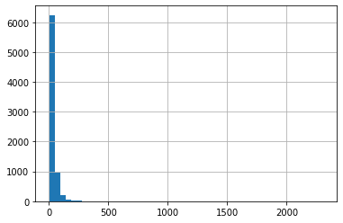

```python
logs_df.groupby('uid')['event'].count().hist(bins=50)
```

```python
logs_df.groupby('uid')['event'].count().sort_values().tail()
```

```
uid
1754140665440434215    1221
6932517045703054087    1439
4623191541214045580    1768
197027893265565660     1998
6304868067479728361    2307
Name: event, dtype: int64
```

`There are some extreme amounts of events per user, so it'd be better to calculate median number of events per user:`

```python
logs_df.groupby('uid')['event'].count().median()
```

```
20.0
```

- What period of time does the data cover? Find the maximum and the minimum date. Plot a histogram by date and time. Can you be sure that you have equally complete data for the entire period? Older events could end up in some users' logs for technical reasons, and this could skew the overall picture. Find the moment at which the data starts to be complete and ignore the earlier section. What period does the data actually represent?
  - Did you lose many events and users when excluding the older data?
  - Make sure you have users from all three experimental groups.

```python
print('The data covers the period between', logs_df.date.min(), 'and', logs_df.date.max())
```

```
The data covers the period between 2019-07-25 and 2019-08-07
```

`Let's check if all the dates are represented evenly:`

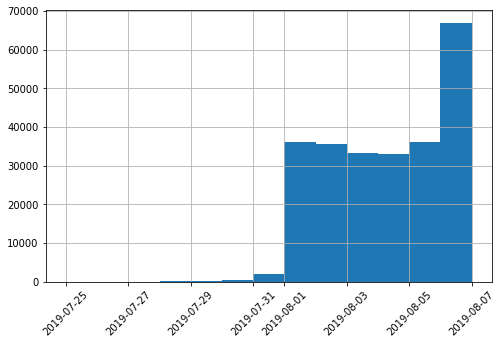

```python
logs_df['date'].hist(bins=13, figsize=(8,5), xrot=45)
```

`It looks like the experiment started on 01.08, the data before might be the pre-test group forming or other preparations. We should work with data from the actual experiment.`

```python
old_idx = logs_df.loc[logs_df['date'] < pd.to_datetime('2019-08-01')].index
print('Users before:',logs_df.uid.nunique())
logs_df = logs_df.drop(index=old_idx)
print('Users after:',logs_df.uid.nunique())
```

```
Users before: 7551
Users after: 7534
```

```python
len(old_idx)
```

```
2826
```

```python
logs_df.groupby('group').uid.nunique()
```

```
group
246    2484
247    2513
248    2537
Name: uid, dtype: int64
```

`The data loss was insignificant after deletion of the dates before 01.08.`

### Step 3. Funnel analysis

- See what events are in the logs and their frequency of occurrence. Sort them by frequency.
- Find the number of users who performed each of these actions. Sort the events by the number of users. Calculate the proportion of users who performed the action at least once.
- In what order do you think the actions took place. Are all of them part of a single sequence? You don't need to take them into account when calculating the funnel.

```python
events_vc = logs_df.event.value_counts().to_frame()
events_vc
```

|  | event |
| --- | --- |
| MainScreenAppear | 117328 |
| OffersScreenAppear | 46333 |
| CartScreenAppear | 42303 |
| PaymentScreenSuccessful | 33918 |
| Tutorial | 1005 |

```python
all_actions_s = logs_df.groupby('uid')['event'].nunique()
print(all_actions_s.loc[all_actions_s.values == 5].count(), 'users performed all 5 actions')
```

```
466 users performed all 5 actions
```

```python
all_actions_no_t = logs_df.query('event != "Tutorial"').groupby('uid')['event'].nunique()
print(all_actions_no_t.loc[all_actions_no_t.values == 4].count(), 'users performed 4 actions without Tutorial')
```

```
3429 users performed 4 actions without Tutorial
```

- Use the event funnel to find the share of users that proceed from each stage to the next. (For instance, for the sequence of events A → B → C, calculate the ratio of users at stage B to the number of users at stage A and the ratio of users at stage C to the number at stage B.)
- At what stage do you lose the most users?
- What share of users make the entire journey from their first event to payment?

```python
events_count = logs_df.groupby('event')['uid'].nunique().sort_values(ascending=False)
events = pd.concat([events_count, events_vc], join='inner', axis=1).reset_index()
events.columns = ['event', 'user_count', 'event_count']
events['proportion_of_unique'] = (events['user_count'] / events['event_count'])
events.style.format({'proportion_of_unique': '{:,.2%}'.format})
```

|  | event | user_count | event_count | proportion_of_unique |
| --- | --- | --- | --- | --- |
| 0 | MainScreenAppear | 7419 | 117328 | 6.32% |
| 1 | OffersScreenAppear | 4593 | 46333 | 9.91% |
| 2 | CartScreenAppear | 3734 | 42303 | 8.83% |
| 3 | PaymentScreenSuccessful | 3539 | 33918 | 10.43% |
| 4 | Tutorial | 840 | 1005 | 83.58% |

```python
colors = list(reversed(px.colors.sequential.Greens[2:6]))
y_val = events.iloc[0:4, 0]
x_val = events.iloc[0:4, 1]
fig = go.Figure(go.Funnel(
    y = y_val,
    x = x_val,
    textposition = "inside",
    textinfo = "value+percent initial",
    opacity = 0.85, marker = {'color' : colors})
    )
fig.update_layout(title={
        'text': "Sales Funnel",
        'y':0.9,
        'x':0.5,
        'xanchor': 'center',
        'yanchor': 'top'})
fig.show()
```

[interactive chart not shown]

`The logical event order is shown on the funnel: Main Screen, then Offer Screen, then Cart Screen, and Payment Succesful Screen. 48% of users who sees the Main screen, make it to succesful payment.`

```python
fnl = logs_df.groupby('event')['uid'].nunique().sort_values(ascending=False).reset_index()
fnl['% of previous stage'] = (100 - 100 * abs(fnl['uid'].pct_change()).fillna(0)).astype(int)
fnl
```

|  | event | uid | % of previous stage |
| --- | --- | --- | --- |
| 0 | MainScreenAppear | 7419 | 100 |
| 1 | OffersScreenAppear | 4593 | 61 |
| 2 | CartScreenAppear | 3734 | 81 |
| 3 | PaymentScreenSuccessful | 3539 | 94 |
| 4 | Tutorial | 840 | 23 |

### Step 4. The results of the experiment

- How many users are there in each group?
- We have two control groups in the A/A test, where we check our mechanisms and calculations. See if there is a statistically significant difference between samples 246 and 247.

```python
groups = logs_df.groupby('group')['uid'].nunique().reset_index()
groups
```

|  | group | uid |
| --- | --- | --- |
| 0 | 246 | 2484 |
| 1 | 247 | 2513 |
| 2 | 248 | 2537 |

`There are 2484 users in group A, 2513 in group B, 2537 in group C.`

```python
if (round(1 - (groups.iloc[0,1]/groups.iloc[1,1]), 2) <= 0.01):
    print('The groups are almost equal in size.')
else:
    print('The groups size difference is too big!')
```

```
The groups are almost equal in size.
```

```python
if (round(1 - (groups.iloc[1,1]/groups.iloc[2,1]), 2) <= 0.01):
    print('The groups are almost equal in size.')
else:
    print('The groups size difference is too big!')
```

```
The groups are almost equal in size.
```

`There are no significant difference in group sizes.`

```python
groups_aa = logs_df.loc[logs_df['group'] != 248]
```

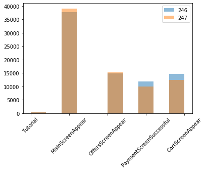

```python
plt.hist(groups_aa[groups_aa['group'] == 246]['event'], alpha=0.5, label='246')
plt.hist(groups_aa[groups_aa['group'] == 247]['event'], alpha=0.5, label='247')
plt.xticks(rotation=45)
plt.legend(loc='upper right')
plt.show()
```

`The distribution of events looks very similar.`

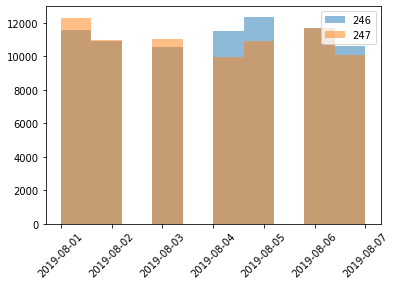

```python
plt.hist(groups_aa[groups_aa['group'] == 246]['date'], alpha=0.5, label='246')
plt.hist(groups_aa[groups_aa['group'] == 247]['date'], alpha=0.5, label='247')
plt.xticks(rotation=45)
plt.legend(loc='upper right')
plt.show()
```

`We have a little more data on the last four days for group 246.`

`Let's check the differencies with z-test:`

$H_{0}$ - There is no statistically significant difference between the groups in user actions.  
$H_{a}$ - There is statistically significant difference between the groups.

```python
pivot = logs_df.pivot_table(index='event', values='uid',
                                    columns='group', aggfunc='nunique').reset_index()#.sort_values(by=(246), ascending=False)
```

```python
pivot
```

| group | event | 246 | 247 | 248 |
| --- | --- | --- | --- | --- |
| 0 | CartScreenAppear | 1266 | 1238 | 1230 |
| 1 | MainScreenAppear | 2450 | 2476 | 2493 |
| 2 | OffersScreenAppear | 1542 | 1520 | 1531 |
| 3 | PaymentScreenSuccessful | 1200 | 1158 | 1181 |
| 4 | Tutorial | 278 | 283 | 279 |

```python
def check_hyp(group1, group2, event, alpha):
    successes1 = pivot[pivot['event'] == event][group1].iloc[0]
    successes2 = pivot[pivot['event'] == event][group2].iloc[0]
    if (isinstance(group1, str)):
        trials1 = logs_df[logs_df['group'] == 247]['uid'].nunique() + logs_df[logs_df['group'] == 246]['uid'].nunique()
    else:
        trials1 = logs_df[logs_df['group'] == group1]['uid'].nunique()

    trials2 = logs_df[logs_df['group'] == group2]['uid'].nunique()

# success proportion in the first group:
    p1 = successes1/trials1

# success proportion in the second group:
    p2 = successes2/trials2

# success proportion in the combined dataset:
    p_combined = (successes1 + successes2) / (trials1 + trials2)

# the difference between the datasets' proportions
    difference = p1 - p2
# calculating the statistic in standard deviations of the standard normal distribution
    z_value = difference / mth.sqrt(p_combined * (1 - p_combined) * (1/trials1 + 1/trials2))

# setting up the standard normal distribution (mean 0, standard deviation 1)
    distr = st.norm(0, 1)

    p_value = (1 - distr.cdf(abs(z_value))) * 2

    print('p-value: ', p_value)

    if (p_value < alpha):
        print("Rejecting the null hypothesis: there is a significant difference between the proportions in", event, 'event.')
    else:
        print("Failed to reject the null hypothesis: there is no reason to consider the proportions different in",
              event, 'event.')
```

```python
for i in pivot.event.unique():
    check_hyp(246, 247, i, 0.05)
```

```
p-value:  0.22883372237997213
Failed to reject the null hypothesis: there is no reason to consider the proportions different in CartScreenAppear event.
p-value:  0.7570597232046099
Failed to reject the null hypothesis: there is no reason to consider the proportions different in MainScreenAppear event.
p-value:  0.2480954578522181
Failed to reject the null hypothesis: there is no reason to consider the proportions different in OffersScreenAppear event.
p-value:  0.11456679313141849
Failed to reject the null hypothesis: there is no reason to consider the proportions different in PaymentScreenSuccessful event.
p-value:  0.9376996189257114
Failed to reject the null hypothesis: there is no reason to consider the proportions different in Tutorial event.
```

`There is no statistically significant difference between the samples 246 and 247.`

- Select the most popular event. In each of the control groups, find the number of users who performed this action. Find their share. Check whether the difference between the groups is statistically significant. Repeat the procedure for all other events (it will save time if you create a special function for this test). Can you confirm that the groups were split properly?

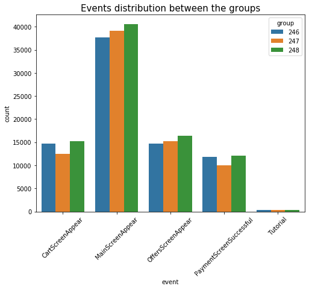

```python
plt.figure(figsize=(8,6))
sns.countplot(x='event', hue='group', data=logs_df)
plt.xticks(rotation=45)
#plt.xlabel('Est. type')
#plt.ylabel('Est. count')
plt.title('Events distribution between the groups', fontsize=15)
```

`For all the groups MainScreenAppear is the most popular event.`

```python
groups_funnel = logs_df.pivot_table(index='event', values='uid',
                                    columns='group', aggfunc='nunique').sort_values(by=(246), ascending=False)
colors1 = list(reversed(px.colors.sequential.Greens[2:6]))
colors2 = list(reversed(px.colors.sequential.Blues[2:6]))
colors3 = list(reversed(px.colors.sequential.Oranges[2:6]))
```

`The event was performed by 2450 unique users in group 246 and by 2476 users in group 247.`

```python
fig = go.Figure()

fig.add_trace(go.Funnel(
    name = '246',
    y = groups_funnel.index,
    x = groups_funnel.iloc[0:4, 0].tolist(),
    textinfo = "value+percent initial", marker = {'color' : colors1}))

fig.add_trace(go.Funnel(
    name = '247',
    orientation = "h",
    y = groups_funnel.index,
    x = groups_funnel.iloc[0:4, 1].tolist(),
    textposition = "inside",
    textinfo = "value+percent initial", marker = {'color' : colors2}))

fig.add_trace(go.Funnel(
    name = '248',
    orientation = "h",
    y = groups_funnel.index,
    x = groups_funnel.iloc[0:4, 2].tolist(),
    textposition = "inside",
    textinfo = "value+percent initial", marker = {'color' : colors3}))

fig.update_layout(title={
        'text': "Sales Funnel by groups",
        'y':0.9,
        'x':0.5,
        'xanchor': 'center',
        'yanchor': 'top'})
fig.show()
```

[interactive chart not shown]

```
The share of the first event to total events for the groups 246 and 247 is 37.9% and 38.7% respectively.

After the runned z-test we may confirm that the control samples were split properly.
```

- Do the same thing for the group with altered fonts. Compare the results with those of each of the control groups for each event in isolation. Compare the results with the combined results for the control groups. What conclusions can you draw from the experiment?

$H_{0}$ - There is no statistically significant difference between the groups in user actions.  
$H_{a}$ - There is statistically significant difference between the groups.

```python
for i in pivot.event.unique():
    check_hyp(246, 248, i, 0.05)
```

```
p-value:  0.07842923237520116
Failed to reject the null hypothesis: there is no reason to consider the proportions different in CartScreenAppear event.
p-value:  0.2949721933554552
Failed to reject the null hypothesis: there is no reason to consider the proportions different in MainScreenAppear event.
p-value:  0.20836205402738917
Failed to reject the null hypothesis: there is no reason to consider the proportions different in OffersScreenAppear event.
p-value:  0.2122553275697796
Failed to reject the null hypothesis: there is no reason to consider the proportions different in PaymentScreenSuccessful event.
p-value:  0.8264294010087645
Failed to reject the null hypothesis: there is no reason to consider the proportions different in Tutorial event.
```

```python
for i in pivot.event.unique():
    check_hyp(247, 248, i, 0.05)
```

```
p-value:  0.5786197879539783
Failed to reject the null hypothesis: there is no reason to consider the proportions different in CartScreenAppear event.
p-value:  0.4587053616621515
Failed to reject the null hypothesis: there is no reason to consider the proportions different in MainScreenAppear event.
p-value:  0.9197817830592261
Failed to reject the null hypothesis: there is no reason to consider the proportions different in OffersScreenAppear event.
p-value:  0.7373415053803964
Failed to reject the null hypothesis: there is no reason to consider the proportions different in PaymentScreenSuccessful event.
p-value:  0.765323922474501
Failed to reject the null hypothesis: there is no reason to consider the proportions different in Tutorial event.
```

```python
pivot['combined'] = pivot[246] + pivot[247]
for i in pivot.event.unique():
    check_hyp('combined', 248, i, 0.05)
```

```
p-value:  0.18175875284404386
Failed to reject the null hypothesis: there is no reason to consider the proportions different in CartScreenAppear event.
p-value:  0.29424526837179577
Failed to reject the null hypothesis: there is no reason to consider the proportions different in MainScreenAppear event.
p-value:  0.43425549655188256
Failed to reject the null hypothesis: there is no reason to consider the proportions different in OffersScreenAppear event.
p-value:  0.6004294282308704
Failed to reject the null hypothesis: there is no reason to consider the proportions different in PaymentScreenSuccessful event.
p-value:  0.764862472531507
Failed to reject the null hypothesis: there is no reason to consider the proportions different in Tutorial event.
```

`There seems to be no statistically significant difference between any control groups, including combined, and the group with altered fonts. The share of user actions remains roughly the same.`

- What significance level have you set to test the statistical hypotheses mentioned above? Calculate how many statistical hypothesis tests you carried out. With a statistical significance level of 0.1, one in 10 results could be false. What should the significance level be? If you want to change it, run through the previous steps again and check your conclusions.

`The significance level of the initial test was 0.05. There were 20 tests conducted, so to minimize FWER we may use the Bonferroni correction (significance level / number of tests):`

```python
a = 0.05/20
a
```

```
0.0025
```

```python
for i in pivot.event.unique():
    check_hyp(246, 247, i, a)
```

```
p-value:  0.22883372237997213
Failed to reject the null hypothesis: there is no reason to consider the proportions different in CartScreenAppear event.
p-value:  0.7570597232046099
Failed to reject the null hypothesis: there is no reason to consider the proportions different in MainScreenAppear event.
p-value:  0.2480954578522181
Failed to reject the null hypothesis: there is no reason to consider the proportions different in OffersScreenAppear event.
p-value:  0.11456679313141849
Failed to reject the null hypothesis: there is no reason to consider the proportions different in PaymentScreenSuccessful event.
p-value:  0.9376996189257114
Failed to reject the null hypothesis: there is no reason to consider the proportions different in Tutorial event.
```

`No change for control group comparisson.`

```python
for i in pivot.event.unique():
    check_hyp(246, 248, i, a)
```

```
p-value:  0.07842923237520116
Failed to reject the null hypothesis: there is no reason to consider the proportions different in CartScreenAppear event.
p-value:  0.2949721933554552
Failed to reject the null hypothesis: there is no reason to consider the proportions different in MainScreenAppear event.
p-value:  0.20836205402738917
Failed to reject the null hypothesis: there is no reason to consider the proportions different in OffersScreenAppear event.
p-value:  0.2122553275697796
Failed to reject the null hypothesis: there is no reason to consider the proportions different in PaymentScreenSuccessful event.
p-value:  0.8264294010087645
Failed to reject the null hypothesis: there is no reason to consider the proportions different in Tutorial event.
```

```python
for i in pivot.event.unique():
    check_hyp(247, 248, i, a)
```

```
p-value:  0.5786197879539783
Failed to reject the null hypothesis: there is no reason to consider the proportions different in CartScreenAppear event.
p-value:  0.4587053616621515
Failed to reject the null hypothesis: there is no reason to consider the proportions different in MainScreenAppear event.
p-value:  0.9197817830592261
Failed to reject the null hypothesis: there is no reason to consider the proportions different in OffersScreenAppear event.
p-value:  0.7373415053803964
Failed to reject the null hypothesis: there is no reason to consider the proportions different in PaymentScreenSuccessful event.
p-value:  0.765323922474501
Failed to reject the null hypothesis: there is no reason to consider the proportions different in Tutorial event.
```

```python
for i in pivot.event.unique():
    check_hyp('combined', 248, i, a)
```

```
p-value:  0.18175875284404386
Failed to reject the null hypothesis: there is no reason to consider the proportions different in CartScreenAppear event.
p-value:  0.29424526837179577
Failed to reject the null hypothesis: there is no reason to consider the proportions different in MainScreenAppear event.
p-value:  0.43425549655188256
Failed to reject the null hypothesis: there is no reason to consider the proportions different in OffersScreenAppear event.
p-value:  0.6004294282308704
Failed to reject the null hypothesis: there is no reason to consider the proportions different in PaymentScreenSuccessful event.
p-value:  0.764862472531507
Failed to reject the null hypothesis: there is no reason to consider the proportions different in Tutorial event.
```

`No different results for the test group either.`

#### Conclusion:

There are 3 groups presented in the test: two control groups 246 and 247, and one test group 248 with users seeing altered fonts. The control groups were splitted evenly, with no significant difference in size of values. The distribution of events between all the groups looks vefy similar: about 38% of all the events is Main Screen event, than Offer event with 24%, then Cart event with 19% and Payment Succeeded event with 18%. After conducting z-test both with or without FWER correction, there were no significant differencies found in any of the events for any group.

### Step 5. Overall conclusion

As the funnel research was conducted, the path of users through purchase was analysed. It takes four steps for a user to make a purchase. Most of the losses (38%) on that path oocurs after the first step, before a user sees the offers page - perhaps we should find a way to interest users in viewing offers page, since from there chances are high that user will complete his purchace. By now, only 48% of initial users complete their purchases.  
As for the A/A/B test conducted, no statistically significant differences were found between the test and control groups. The altered fonts seems to have no impact on user behavior.